# Energy landscapes with enerscape

Emilio Berti

12/18/2020

# General usage

Enerscape computes the energy landscape based on models predicting the energy costs of transport. Two models are currently implemented, the ARC model from (Pontzer 2016) and the model for cycling expenditures from (Prampero et al. 1979). Adding other models is relatively easy and can be done by writing a custom function in the *enerscape_internals.R* script. Currently, there is no implementation for user-specified models, but I plan to add this in the future.

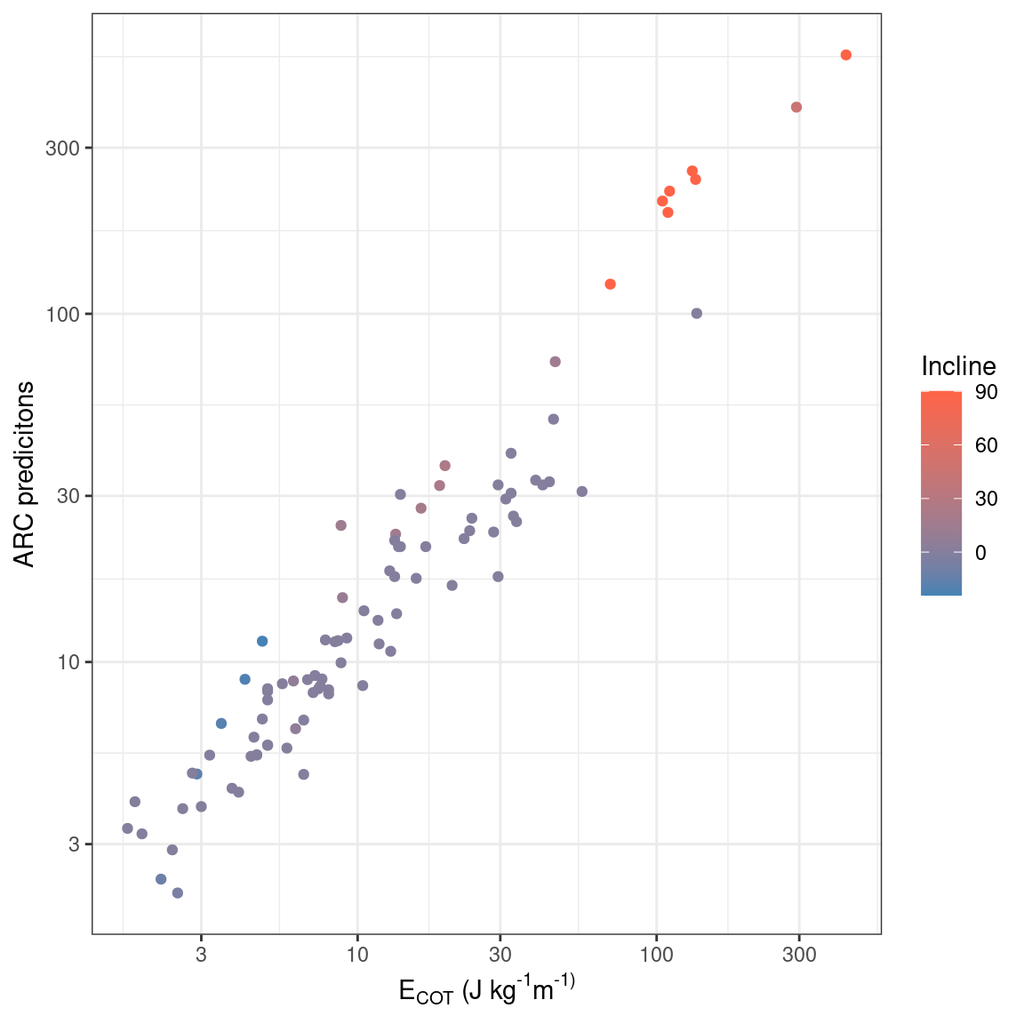

```r
library(tidyverse)
library(raster)
library(sf)
library(enerscape)

#' Function to plot the areas
#' @param x is a raster
#' @param poly is a shapefile polygon
plot_area <- function(x, poly, mask = NULL, col = NULL, void = FALSE) {
  if (is.null(col)) {
    plot(x, axes = !void, box = !void)
  } else {
    plot(x, col = col, axes = !void, box = !void)
  }
  if (!is.null(mask)) {
    plot(mask, add = T, legend = FALSE,
       col = adjustcolor("white", alpha.f = 0.5),
       axes = !void,
       box = !void)
  }
  plot(poly$geometry, add = TRUE)
}

ARC <- function(mass, slope) {
  E_ar <- 8 * mass ^ (-0.34)
  E_mec <- 100 * (1 + sin((2 * slope - 74) / 180 * pi)) * mass ^ (-0.12)
  E <- (E_ar + E_mec)
  return(E)
}

pontzer %>%
  as_tibble %>%
  mutate(ARC = ARC(Mass, Incline)) %>%
  ggplot() +
  geom_point(aes(Cost.of.Transport, ARC, col = Incline)) +
  scale_color_gradient(low = "steelblue", high = "tomato") +
  scale_x_log10() +
  scale_y_log10() +
  xlab(expression("E"["COT"]*" (J kg"^"-1"*"m"^"-1)")) +
  ylab("ARC predicitons") +
  theme_bw()
```

# Landscape connectivity for the Marsican bear (*Ursus arctos marsicanus*) in the Sirente-Velino Regional Park.

The required input for enerscape using the ARC model are:

- body mass of the animal (kg)
- a digital elevation model (DEM) of the area of interest (m)

I load the DEM and the park polygon data.

```r
dem <- raster("../data/dem-vignette.tif")
park <- st_read("../data/SVRP-polygon.shp")
```

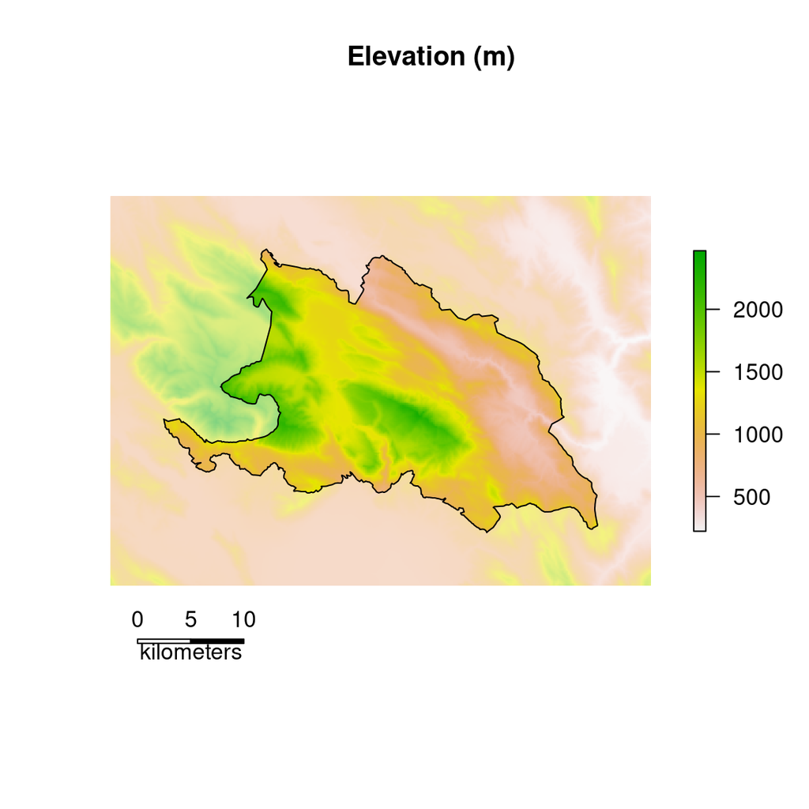

```r
m <- mask(dem, park, inverse = TRUE)
plot_area(dem, park, m, void = TRUE)
title("Elevation (m)")
scalebar(10000,
         type = "bar",
         divs = 2,
         label = as.character(c(0, 5, 10)),
         below = "kilometers")
```

I calculate the energy landscape for a bear of 140 kg.

```r
en <- enerscape(dem, 140, "kcal")
plot(en$rasters, axes = FALSE, box = FALSE)
```

[output not shown]

I initialize the *omniscape.ini* file to be passed to Julia.

```r
omniscape_skeleton(en,
                   file.path("/home",
                             "eb97ziwi",
                             "Proj",
                             "enerscape-paper",
                             "data"),
                   radius = 10)
```

And I run the Omniscape algorithm in a Julia terminal. Don’t forget to specify the number of parallel threads: https://docs.circuitscape.org/Omniscape.jl/stable/usage/#Parallel-Processing.

```r
julia> using Omniscape
julia> run_omniscape("/home/eb97ziwi/Proj/enerscape-paper/data/mols/omniscape.ini")
```

[output not shown]

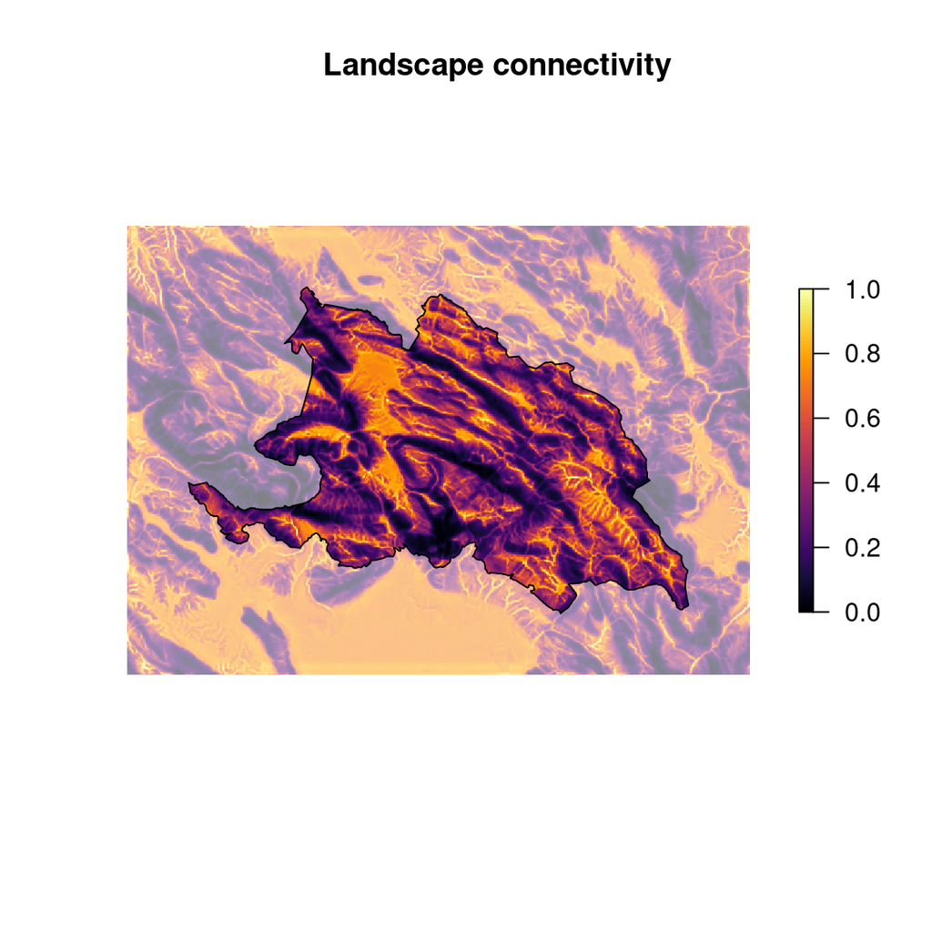

```r
os <- raster("../data/omniscape_1/cum_currmap.tif")
os <- os - min(values(os), na.rm = TRUE)
os[os >= quantile(os, 0.999)] <- quantile(os, 0.999) #remove far outliers
os <- os / max(values(os), na.rm = TRUE)
plot_area(os,
          park,
          m,
          col = viridis::inferno(100),
          void = TRUE)
title("Landscape connectivity")
```

Pontzer, Herman. 2016. “A Unified Theory for the Energy Cost of Legged Locomotion.” *Biology Letters* 12 (2): 20150935. https://doi.org/10.1098/rsbl.2015.0935.

Prampero, P. E. di, G. Cortili, P. Mognoni, and F. Saibene. 1979. “Equation of Motion of a Cyclist.” *Journal of Applied Physiology* 47 (1): 201–6. https://doi.org/10.1152/jappl.1979.47.1.201.